# Script5_Armbruster2026_PandeyIntegration_QC-Filtering

Daniel Armbruster

2026-07-24

- This script performed quality control, preprocessing, and merging of the published telencephalon 10X-based scRNAseq dataset from Pandey et al. 2023 (10.1101/gr.277278.122) with subsets of the annotated CA dataset we generated in Script 3.
- The published whole telencephalon dataset consists of samples derived from 6 dpf, 15 dpf and adult zebrafish and was deposited as mapped barcode, features and matrix files in the NCBI Gene Expression Omnibus under the accession number GSE212314.
- The session info including the used packages and their versions is provided at the end of this script.

# 1. Load Packages

```r
library(Seurat)
library(dplyr)
library(ggplot2)
```

# 2. Load Data and Generate Seurat Object

```r
# Load mapped output from the published dataset and generate a list of sample-specific Seurat objects with initial filtering of cells expressing fewer than 200 genes.
directory <- "Resources/Pandey2023_mapped/"
dir_lists <- basename(list.dirs(path = directory, full.names = TRUE))[-1]
pandey_seurat_objects <- list()
for (dir in dir_lists){
  sparse_matrix <- Read10X(data.dir = paste(directory, dir, "/", sep = ""))
  seurat_object <- CreateSeuratObject(counts = sparse_matrix, min.features = 200)
  pandey_seurat_objects[[dir]] <- seurat_object
}
```

[output not shown]

# 3 Quality Control

## 3.1 Prepare Metadata for QC

- Store genes detected per UMI, mitochondrial counts, cell names, and sample name in metadata
- Rename count and feature columns

```r
for (seurat_object in names(pandey_seurat_objects)) {

  # Extract seurat object to modify from list
  obj <- pandey_seurat_objects[[seurat_object]]

  # Calculate log10-transformed genes per UMI ratio
  obj$log10GenesPerUMI <- log10(obj$nFeature_RNA)/log10(obj$nCount_RNA)

  # Add mitochondrial gene expression percentage
  obj$MTratio <- PercentageFeatureSet(obj, pattern = "mt-*")

  # Add Cell name
  obj$cells <- rownames(obj@meta.data)
  obj@meta.data <- obj@meta.data %>%
    dplyr::rename(nUMI = nCount_RNA, nGene = nFeature_RNA)

  # Add sample ID
  obj$sample <- seurat_object

  #Assign modified seurat object back to list
  pandey_seurat_objects[[seurat_object]] <- obj

}
```

- Extract metadata from each Seurat object and generate a corresponding list for downstream QC assessment

```r
pandey_metadata <- list()

for (seurat_object in names(pandey_seurat_objects)) {
  metadata <- pandey_seurat_objects[[seurat_object]]@meta.data
  pandey_metadata[[seurat_object]] <- metadata
}
```

## 3.2 Assessing QC metrics

## 3.1 Cell number

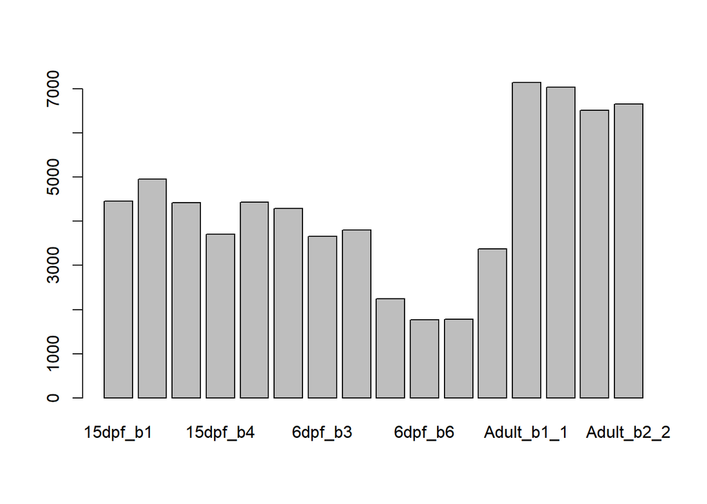

```r
# Plot of cell number
cell_numbers <- list()

for (object in names(pandey_metadata)){
  cell_numbers[[object]] <- length(pandey_metadata[[object]]$cells)
}

barplot(unlist(cell_numbers))
```

## 3.2 Counts per cell

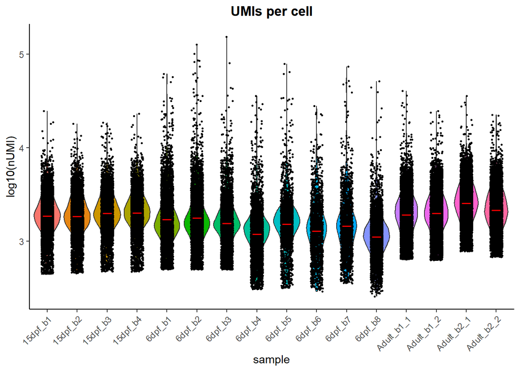

```r
# Visualize the distribution of UMI counts per cell across samples
all_metadata <- bind_rows(pandey_metadata, .id = "sample_id")


nUMI_plot <- ggplot(all_metadata, aes(x = sample, y = log10(nUMI), fill = sample)) +
  geom_violin() +
  geom_jitter(shape = 16, size = 0.5, position = position_jitter(0.2)) +
  stat_summary(fun = mean, geom = "point", size = 5, color = "red", shape = 95) +
  theme_classic() +
  theme(
    legend.position = "none",
    axis.text.x = element_text(angle = 45, vjust = 1, hjust = 1),
    plot.title = element_text(hjust = 0.5, face = "bold")
  ) +
  ggtitle("UMIs per cell")

nUMI_plot
```

## 3.3 Genes per cell

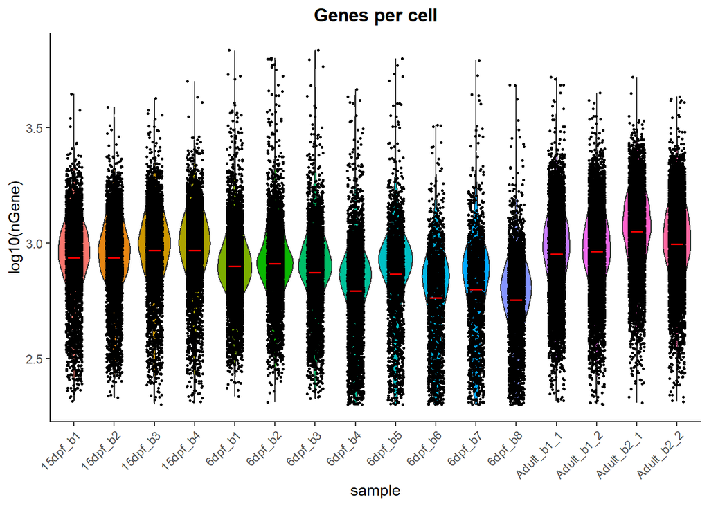

```r
# Visualize the distribution of genes per cell across samples
nGene_plot <- ggplot(all_metadata, aes(x = sample, y = log10(nGene), fill = sample)) +
  geom_violin() +
  geom_jitter(shape = 16, size = 0.5, position = position_jitter(0.2)) +
  stat_summary(fun = mean, geom = "point", size = 5, color = "red", shape = 95) +
  theme_classic() +
  theme(
    legend.position = "none",
    axis.text.x = element_text(angle = 45, vjust = 1, hjust = 1),
    plot.title = element_text(hjust = 0.5, face = "bold")
  ) +
  ggtitle("Genes per cell")

nGene_plot
```

## 3.4 MT content:

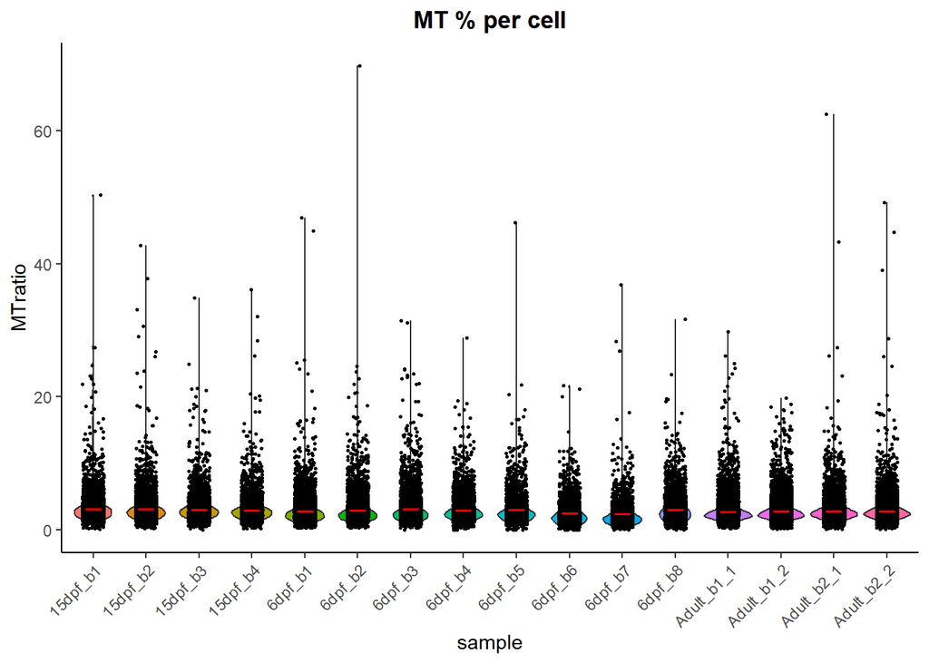

```r
# Visualize the mitochondrial gene content across samples
nMT_plot <- ggplot(all_metadata, aes(x = sample, y =MTratio, fill = sample)) +
  geom_violin() +
  geom_jitter(shape = 16, size = 0.5, position = position_jitter(0.2)) +
  stat_summary(fun = mean, geom = "point", size = 5, color = "red", shape = 95) +
  theme_classic() +
  theme(
    legend.position = "none",
    axis.text.x = element_text(angle = 45, vjust = 1, hjust = 1),
    plot.title = element_text(hjust = 0.5, face = "bold")
  ) +
  ggtitle("MT % per cell")

nMT_plot
```

# 4. Loading and preparing forebrain seurat object from figure 4

```r
# Load annotated forebrain Seurat object generated in Script 3
vFB_cells <- readRDS(file = "D:/scRNAseq/10X/DA136/SeuratAnalysis_2024-09-03/RDS_files/Script3_Armbruster2026_annotated.rds")

# Subset the ventral forebrain/progenitor and olfactory bulb clusters and remve unnecessary metadata from previous analyses
vFB_cells <- subset(vFB_cells, idents=c("vFb/Prog1","vFb/Prog2", "OB"))
vFB_cells$pANN_0.25_0.22_271 <- NULL
vFB_cells$DF.classifications_0.25_0.22_271 <- NULL
vFB_cells$S.Score <- NULL
vFB_cells$G2M.Score <- NULL
vFB_cells$Phase <- NULL
vFB_cells$nCount_SCT <- NULL
vFB_cells$nFeature_SCT <- NULL
vFB_cells$seurat_clusters <- NULL
vFB_cells$SCT_snn_res.1 <- NULL
vFB_cells$EGFPratio <- NULL
vFB_cells$dataset <- "5dpf_own"
```

# 5. Harmonize gene symbols and merging

```r
#### ----- Extract count matrices and metadata, then convert gene symbols to Ensembl IDs ----- ####
# Both datasets were generated using the same zebrafish reference genome but different Ensembl releases. As gene symbols might differ, we will convert them back to Ensembl IDs prior merging.

## Merge all published Pandey samples into a single Seurat object
pandey_merged <- Reduce(function(x, y) merge(x, y), pandey_seurat_objects)
pandey_merged$dataset <- "pandey"

# Load gene feature table and convert gene symbols to Ensembl identifiers
pandey_features <- read.csv(
  "D:/scRNAseq/10X/DA136/SeuratAnalysis_2024-09-03/Resources/pandey_features.tsv",
  sep = "\t",
  header = FALSE,
  col.names = c("ensembl.id", "gene.symbol", "column3"))
matched_ids_pandey <- pandey_features$ensembl.id[match(rownames(pandey_merged), pandey_features$gene.symbol)]
pandey_merged <- pandey_merged[!is.na(matched_ids_pandey), ]
rownames(pandey_merged) <- matched_ids_pandey[!is.na(matched_ids_pandey)]
```

```r
# Convert gene symbols of own dataset to Ensembl identifiers
own_features <- read.csv(
  "D:/scRNAseq/10X/DA136/SeuratAnalysis_2024-09-03/Resources/own_features.tsv",
  sep = "\t",
  header = FALSE,
  col.names = c("ensembl.id", "gene.symbol", "column3")
)

# Extract count matrix and metadata from own Seurat object
own_counts <- GetAssayData(vFB_cells,assay = "RNA", slot = "counts")
```

```r
own_meta <- vFB_cells@meta.data

# Convert gene symbols to Ensembl identifiers and recreate Seurat object
matched_ids_own <- own_features$ensembl.id[match(rownames(own_counts), own_features$gene.symbol)]
own_counts <- own_counts[!is.na(matched_ids_own), ]
rownames(own_counts) <- matched_ids_own[!is.na(matched_ids_own)]
vFB_cells <- CreateSeuratObject(counts = own_counts, meta.data = own_meta, project = "Own")

# Retain only genes shared between both datasets
common_genes <- intersect(rownames(pandey_merged), rownames(vFB_cells))
pandey_merged <- subset(pandey_merged, features = common_genes)
vFB_cells <- subset(vFB_cells, features = common_genes)

# Merge datasets using common Ensembl identifiers
merged_seurat_object <- merge(pandey_merged, y=vFB_cells)

# Convert Ensembl identifiers back to gene symbols
ensembl_to_own <- setNames(own_features$gene.symbol,
                           own_features$ensembl.id)
mapped_symbols <- unname(ensembl_to_own[rownames(merged_seurat_object)])

# Check if either NA are generated.
sum(is.na(mapped_symbols))
```

```
## [1] 0
```

```r
# Or if their are duplicated gene symbols now
dup_symbols <- mapped_symbols[duplicated(mapped_symbols)]
length(unique(dup_symbols))
```

```
## [1] 0
```

```r
# Neither NAs nor duplicates are generated

# Change the rownames to the mapped symbols
rownames(merged_seurat_object) <- mapped_symbols
```

# 6 Filtering

## 6.1 Cell level filtering

- Filtering thresholds:
  - nGene >500
  - Mtratio < 8 (only cells with less then 8 % mitochondrial reads)

  ```r
  merged_seurat_object_filtered <- subset(x = merged_seurat_object, subset = (nGene >=500 & MTratio < 8))
  ```

## 5.2 Gene level filtering

- Filter out genes with 0 counts over all cells and genes that are not detected in at least 3 cells.

```r
# Only keep genes expressed in at least 3 cells
merged_seurat_object_filtered <- JoinLayers(merged_seurat_object_filtered)
allown_counts <- GetAssayData(object = merged_seurat_object_filtered, layer = "counts")
allown_nonzero <- allown_counts > 0
allown_keep_genes <- Matrix::rowSums(allown_nonzero) >=3
allown_filtered_counts <- allown_counts[allown_keep_genes,]
merged_seurat_object_filtered <- CreateSeuratObject(allown_filtered_counts, meta.data = merged_seurat_object_filtered@meta.data)
```

# 6 Save as RDS file

```r
saveRDS(merged_seurat_object_filtered, file = "RDS_files/Script5_Armbruster2026_Pandey_integ_filtered.rds")
```

```r
# Remove objects to reduce memory usage
rm(list=ls())
gc()
```

```
##           used  (Mb) gc trigger (Mb)  max used   (Mb)
## Ncells 3681359 196.7    6477612  346   6477612  346.0
## Vcells 7400562  56.5  751037044 5730 936295227 7143.4
```